# Scooby Doo

Jo Hardin

7/13/2021

### Alt text!

Thanks to the work of those at RStudio, alt text is easy to add to a figure chunk. I’ve added alt text to each of the figures in this week’s #TidyTuesday. To see the alt text, hover the mouse over the figure, and a text box with a plot description will pop up.

### The Data

The data this week comes from [Kaggle](https://www.kaggle.com/williamschooleman/scoobydoo-complete) thanks to manual data aggregation by [plummye](https://www.kaggle.com/williamschooleman). Hat tip to [Sara Stoudt](https://github.com/rfordatascience/tidytuesday/issues/345) for recommending this dataset!

```r
scooby <- read_csv("scoobydoo.csv")

scooby <- scooby %>%
  mutate(imdb = as.numeric(imdb), engagement = as.numeric(engagement),
         number_of_snacks = as.numeric(number_of_snacks)) %>%
  mutate(monsters_gen = case_when(
    str_detect(monster_gender, "Male") & str_detect(monster_gender,"Female") ~ "Both",
    str_detect(monster_gender, "Male") ~ "Male",
    str_detect(monster_gender, "Female") ~ "Female",
    TRUE ~ "NoGender")) %>%
  mutate(motive2 = case_when(
    motive == "Food" ~ "Food",
    motive == "Preservation" ~ "Preservation",
    motive == "Abduction" ~ "Abduction",
    motive == "Trespassing" ~ "Trespassing",
    motive == "Smuggling" ~ "Smuggling",
    motive == "Natural Resource" ~ "Natural Resource",
    motive == "Conquer" ~ "Conquer",
    motive == "Treasure" ~ "Treasure",
    motive == "Theft" ~ "Theft",
    motive == "Competition" ~ "Competition",
    is.na(motive)  ~ "None",
    TRUE ~ "Other"
  )) %>%
  mutate(year = year(date_aired))
```

### Predicting IMDB

Can we figure out what characteristics of the show will best lead to a high IMDB rating?

#### IMDB as a function of …

Before starting to build a model to predict the rating, I’m going to visualize the IMDB rating as a function of various other variables.

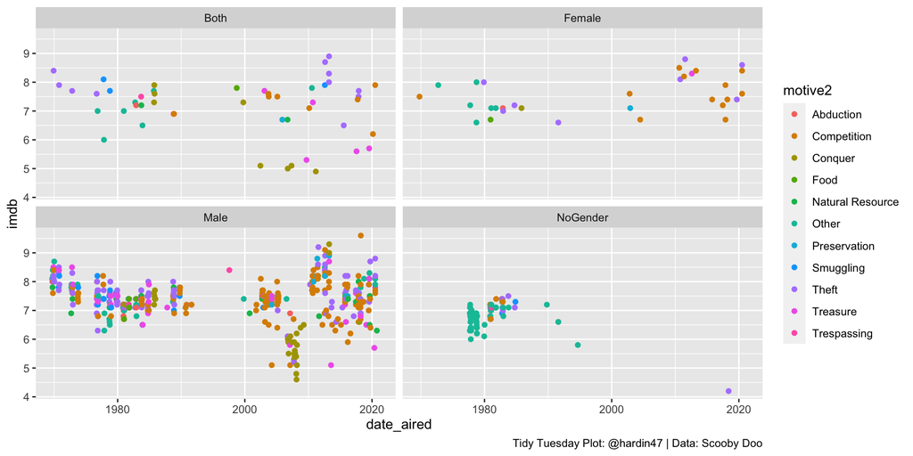

```r
ggplot(scooby) +
  geom_point(aes(x = date_aired, y = imdb, color = motive2)) +
  facet_wrap(~ monsters_gen) +
  labs(caption = "Tidy Tuesday Plot: @hardin47 | Data: Scooby Doo")
```

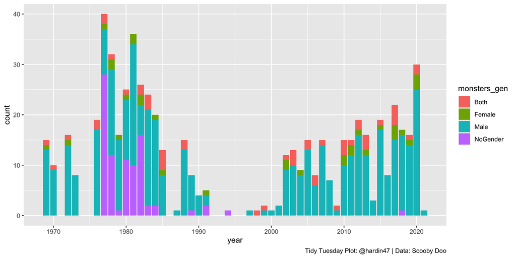

```r
scooby %>%
  group_by(year, monsters_gen) %>%
  summarize(count = n()) %>%
  ungroup %>%
ggplot() +
  geom_bar(stat = "identity", aes(x = year, count,
                                  group = monsters_gen,
                                  fill = monsters_gen)) +
  labs(caption = "Tidy Tuesday Plot: @hardin47 | Data: Scooby Doo")
```

## A model

Back to practicing tidy models…

#### test & training data

```r
scooby_small <- scooby %>%
  select(imdb, season, run_time, monsters_gen, monster_amount,
         starts_with("caught"), starts_with("captured"),
         starts_with("unmask"), starts_with("snack"),
         suspects_amount, motive2, culprit_amount,
         number_of_snacks, batman, scooby_dum, scrappy_doo,
         hex_girls, blue_falcon) %>%
  drop_na()

set.seed(47)

data_split <- initial_split(scooby_small, prop = 2/3)

scooby_train <- training(data_split)
scooby_test <- testing(data_split)
```

#### recipe

```r
scooby_rec <-
  recipe(imdb ~ ., data = scooby_train)

summary(scooby_rec)
```

```
## # A tibble: 37 x 4
##    variable       type    role      source
##    <chr>          <chr>   <chr>     <chr>
##  1 season         nominal predictor original
##  2 run_time       numeric predictor original
##  3 monsters_gen   nominal predictor original
##  4 monster_amount numeric predictor original
##  5 caught_fred    nominal predictor original
##  6 caught_daphnie nominal predictor original
##  7 caught_velma   nominal predictor original
##  8 caught_shaggy  nominal predictor original
##  9 caught_scooby  nominal predictor original
## 10 caught_other   logical predictor original
## # … with 27 more rows
```

#### set the model

```r
rf_mod1 <-
  rand_forest(mtry = 5,
              trees = 500,
              min_n = 5) %>%
  set_engine("ranger", importance = "permutation") %>%
  set_mode("regression")
```

#### fit the model

After we’ve specified the engine, we can then `fit()` the model:

```r
set.seed(4747)
scooby_rf1 <-
  workflow() %>%
  add_model(rf_mod1) %>%
  add_recipe(scooby_rec) %>%
  fit(data = scooby_train)

scooby_rf1
```

```
## ══ Workflow [trained] ══════════════════════════════════════════════════════════
## Preprocessor: Recipe
## Model: rand_forest()
##
## ── Preprocessor ────────────────────────────────────────────────────────────────
## 0 Recipe Steps
##
## ── Model ───────────────────────────────────────────────────────────────────────
## Ranger result
##
## Call:
##  ranger::ranger(x = maybe_data_frame(x), y = y, mtry = min_cols(~5,      x), num.trees = ~500, min.node.size = min_rows(~5, x), importance = ~"permutation",      num.threads = 1, verbose = FALSE, seed = sample.int(10^5,          1))
##
## Type:                             Regression
## Number of trees:                  500
## Sample size:                      356
## Number of independent variables:  36
## Mtry:                             5
## Target node size:                 5
## Variable importance mode:         permutation
## Splitrule:                        variance
## OOB prediction error (MSE):       0.2416005
## R squared (OOB):                  0.5561264
```

#### model fit

##### vip

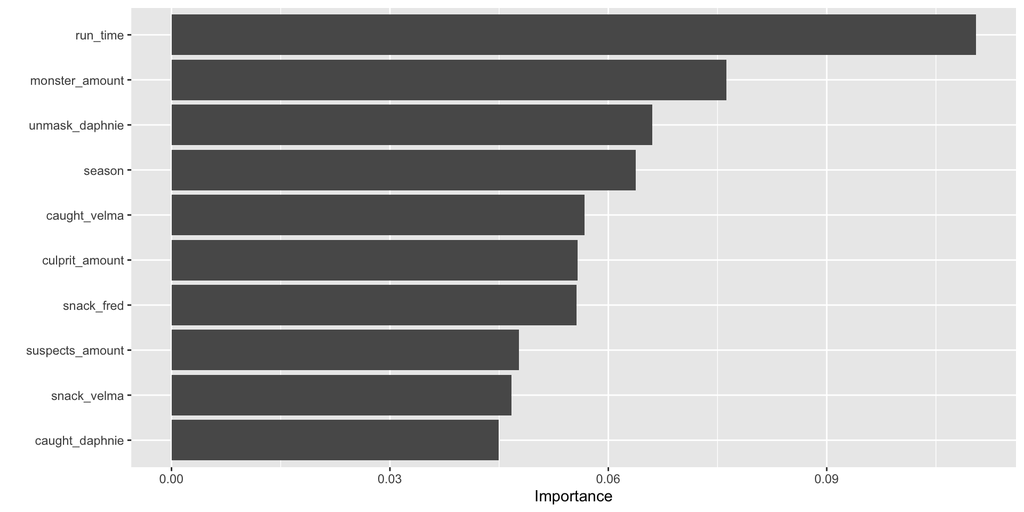

```r
library(vip)

scooby_rf1 %>%
  pull_workflow_fit() %>%
  vip()
```

##### observed vs predicted

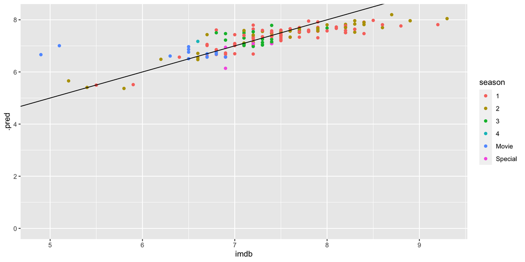

```r
scooby_test %>%
  cbind(predict(scooby_rf1, new_data = scooby_test)) %>%
  ggplot() +
  geom_point(aes(x = imdb, y = .pred, color = season)) +
  geom_abline(slope = 1, intercept = 0)
```

# Julia Silge’s screencast

[Julia did a tidymodel](https://juliasilge.com/blog/scooby-doo/) to predict whether or not the monster is real. I’m just going to copy her code directly to walk through the process of building a tidymodel.

```r
scooby %>%
  filter(monster_amount > 0) %>%
  count(monster_real)
```

```
## # A tibble: 2 x 2
##   monster_real     n
##   <chr>        <int>
## 1 FALSE          404
## 2 TRUE           112
```

How many monsters are real in buckets of 5 years. Notice the trick for empty bars at the ends.

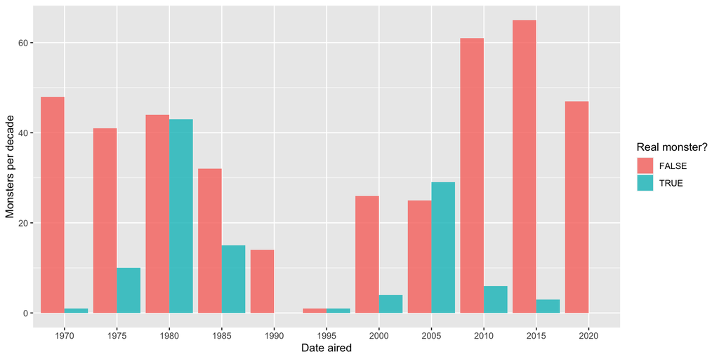

```r
scooby %>%
  filter(monster_amount > 0) %>%
  count(
    year_aired = 5 * ((lubridate::year(date_aired) + 1) %/% 5),
    monster_real
  ) %>%
  mutate(year_aired = factor(year_aired)) %>%
  ggplot(aes(year_aired, n, fill = monster_real)) +
  geom_col(position = position_dodge(preserve = "single"), alpha = 0.8) +
  labs(x = "Date aired", y = "Monsters per decade", fill = "Real monster?")
```

## wrangling the data

Note that the training data is set in an interesting way here. First of all, there is some stratified sampling to make sure that the groups are balanced. But Julia also bootstrapped (within??) each sample. I’m not totally sure.

```r
set.seed(123)
scooby_split <- scooby %>%
  mutate(
    year_aired = lubridate::year(date_aired)
  ) %>%
  filter(monster_amount > 0, !is.na(imdb)) %>%
  mutate(
    monster_real = case_when(
      monster_real == "FALSE" ~ "fake",
      TRUE ~ "real"
    ),
    monster_real = factor(monster_real)
  ) %>%
  select(year_aired, imdb, monster_real, title) %>%
  initial_split(strata = monster_real)
scooby_train <- training(scooby_split)
scooby_test <- testing(scooby_split)

set.seed(234)
scooby_folds <- bootstraps(scooby_train, strata = monster_real)
scooby_folds
```

```
## # Bootstrap sampling using stratification
## # A tibble: 25 x 2
##    splits            id
##    <list>            <chr>
##  1 <split [375/133]> Bootstrap01
##  2 <split [375/144]> Bootstrap02
##  3 <split [375/140]> Bootstrap03
##  4 <split [375/132]> Bootstrap04
##  5 <split [375/139]> Bootstrap05
##  6 <split [375/134]> Bootstrap06
##  7 <split [375/146]> Bootstrap07
##  8 <split [375/132]> Bootstrap08
##  9 <split [375/143]> Bootstrap09
## 10 <split [375/143]> Bootstrap10
## # … with 15 more rows
```

#### set the model

Note that we wouldn’t be able to run the model after this step because we haven’t set the parameters yet. We’ll need to tune them.

```r
tree_spec <-
  decision_tree(
    cost_complexity = tune(),
    tree_depth = tune(),
    min_n = tune()
  ) %>%
  set_mode("classification") %>%
  set_engine("rpart")

tree_spec
```

```
## Decision Tree Model Specification (classification)
##
## Main Arguments:
##   cost_complexity = tune()
##   tree_depth = tune()
##   min_n = tune()
##
## Computational engine: rpart
```

So we set up a grid of possible values to try (using mostly the default tuning values):

```r
tree_grid <- grid_regular(cost_complexity(), tree_depth(), min_n(), levels = 4)
tree_grid
```

```
## # A tibble: 64 x 3
##    cost_complexity tree_depth min_n
##              <dbl>      <int> <int>
##  1    0.0000000001          1     2
##  2    0.0000001             1     2
##  3    0.0001                1     2
##  4    0.1                   1     2
##  5    0.0000000001          5     2
##  6    0.0000001             5     2
##  7    0.0001                5     2
##  8    0.1                   5     2
##  9    0.0000000001         10     2
## 10    0.0000001            10     2
## # … with 54 more rows
```

#### find the model

Now let’s fit each possible parameter combination to each resample. By putting non-default metrics into metric_set(), we can specify which metrics are computed for each resample. There are 25 Bootstrap resamples x 64 possible parameter settings (each time keeping track of the metrics).

```r
doParallel::registerDoParallel()

set.seed(345)
tree_rs <-
  tune_grid(
    tree_spec,
    monster_real ~ year_aired + imdb,
    resamples = scooby_folds,
    grid = tree_grid,
    metrics = metric_set(accuracy, roc_auc, sensitivity, specificity)
  )

tree_rs
```

```
## # Tuning results
## # Bootstrap sampling using stratification
## # A tibble: 25 x 4
##    splits            id          .metrics           .notes
##    <list>            <chr>       <list>             <list>
##  1 <split [375/133]> Bootstrap01 <tibble [256 × 7]> <tibble [0 × 1]>
##  2 <split [375/144]> Bootstrap02 <tibble [256 × 7]> <tibble [0 × 1]>
##  3 <split [375/140]> Bootstrap03 <tibble [256 × 7]> <tibble [0 × 1]>
##  4 <split [375/132]> Bootstrap04 <tibble [256 × 7]> <tibble [0 × 1]>
##  5 <split [375/139]> Bootstrap05 <tibble [256 × 7]> <tibble [0 × 1]>
##  6 <split [375/134]> Bootstrap06 <tibble [256 × 7]> <tibble [0 × 1]>
##  7 <split [375/146]> Bootstrap07 <tibble [256 × 7]> <tibble [0 × 1]>
##  8 <split [375/132]> Bootstrap08 <tibble [256 × 7]> <tibble [0 × 1]>
##  9 <split [375/143]> Bootstrap09 <tibble [256 × 7]> <tibble [0 × 1]>
## 10 <split [375/143]> Bootstrap10 <tibble [256 × 7]> <tibble [0 × 1]>
## # … with 15 more rows
```

#### evaluate model

```r
show_best(tree_rs)
```

```
## # A tibble: 5 x 9
##   cost_complexity tree_depth min_n .metric  .estimator  mean     n std_err
##             <dbl>      <int> <int> <chr>    <chr>      <dbl> <int>   <dbl>
## 1    0.0000000001         10     2 accuracy binary     0.872    25 0.00481
## 2    0.0000001            10     2 accuracy binary     0.872    25 0.00481
## 3    0.0001               10     2 accuracy binary     0.872    25 0.00481
## 4    0.0000000001         15     2 accuracy binary     0.871    25 0.00456
## 5    0.0000001            15     2 accuracy binary     0.871    25 0.00456
## # … with 1 more variable: .config <chr>
```

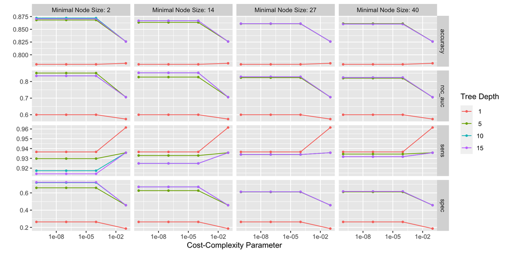

```r
autoplot(tree_rs)
```

Lots of ways to choose “best” … `select_best()` gives the numerically best model (for some metric). Alternatively, we can choose a simpler tree within a small amount of the best metric. A less complex tree might keep us from over fitting.

Now, `final_tree` has the parameter values, so we **can** fit it to the data!

```r
simpler_tree <- select_by_one_std_err(tree_rs,
  -cost_complexity,
  metric = "roc_auc"
)

final_tree <- finalize_model(tree_spec, simpler_tree)
```

#### fit the model

Note the use of the `fit()` functions instead of the `last_fit()` function. The `fit()` function uses only the training data. The `last_fit()` function fits the final best model to the training set and **evaluates** on the test set!

```r
final_fit <- fit(final_tree, monster_real ~ year_aired + imdb, scooby_train)
```

#### on the test data

But we do want to see how the model will work on the test data…

```r
final_rs <- last_fit(final_tree, monster_real ~ year_aired + imdb, scooby_split)
collect_metrics(final_rs)
```

```
## # A tibble: 2 x 4
##   .metric  .estimator .estimate .config
##   <chr>    <chr>          <dbl> <chr>
## 1 accuracy binary         0.857 Preprocessor1_Model1
## 2 roc_auc  binary         0.780 Preprocessor1_Model1
```

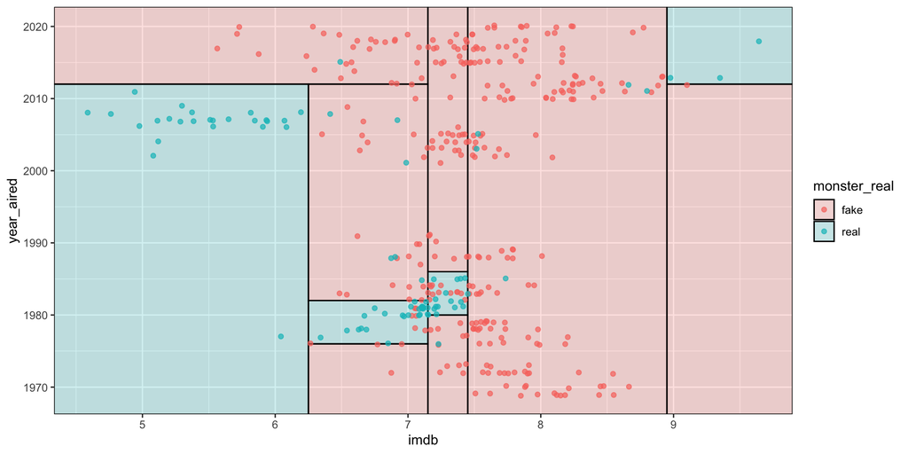

```r
# remotes::install_github("grantmcdermott/parttree")
library(parttree)

scooby_train %>%
  ggplot(aes(imdb, year_aired)) +
  geom_parttree(data = final_fit, aes(fill = monster_real), alpha = 0.2) +
  geom_jitter(alpha = 0.7, width = 0.05, height = 0.2, aes(color = monster_real))
```

# pivoting and summarizing

There were some **great** plots today on Twitter, so I’m trying them out. The code below is mostly due to [@jack_davison](https://github.com/jack-davison/TidyTuesday/tree/master/R).

```r
colors = tribble(
  ~name, ~color,
  "daphnie", "#7C6AA8",
  "shaggy", "#B2BE34",
  "scooby", "#B1752C",
  "velma", "#FA9C39",
  "fred", "#01A0DA"
)

scooby_plot <- scooby %>%
  select(index, year, contains("unmask"), contains("captured"), contains("snack")) %>%
  select(-number_of_snacks) %>%
  mutate(across(-c(index,year), as.logical)) %>%
  pivot_longer(where(is.logical)) %>%
  mutate(activity = str_extract(name, "unmask|captured|snack"),
         name = str_remove(name, "unmask_|captured_|snack_")) %>%
  group_by(year) %>%
  count(name, value, activity) %>%
  filter(value, name != "other") %>%
  left_join(colors, by = "name") %>%
  mutate(name = fct_reorder(name, n, max)) %>%
  mutate(decade = floor(year/10)*10) %>%
  ungroup() %>%
  group_by(decade, name, activity) %>%
  summarise(n_decade = sum(n))
```

[figure not shown]

```r
scooby_plot %>%
  ggplot() +
  geom_line(aes(x = decade, y = n_decade, group = name,
                color = name)) +
  facet_grid(activity~1)
```